# Lecture 36: Lab session

MATH-6040/7260 Linear Models

Dr. Xiang Ji @ Tulane University

April 23, 2021

%

## Reference

We consider the `Machines` and `Cheese` examples in Lukas Meier’s [Lecture notes](https://stat.ethz.ch/~meier/teaching/anova/random-and-mixed-effects-models.html#example-machines-data)

## Q1 Machines example

We start with the data set `Machines` from the package `nlme` (as in Lukas’s notes). As stated in the help file: “Data on an experiment to compare three brands of machines used in an industrial process are presented in Milliken and Johnson (p. 285, 1992). Six workers were chosen randomly among the employees of a factory to operate each machine three times. The response is an overall productivity score taking into account the number and quality of components produced.”

```r
data("Machines", package = "nlme")
## technical detail for nicer output:
Machines[, "Worker"] <- factor(Machines[, "Worker"], levels = 1:6, ordered = FALSE)
str(Machines, give.attr = FALSE) ## give.attr in order to shorten output
```

```
## Classes 'nffGroupedData', 'nfGroupedData', 'groupedData' and 'data.frame':   54 obs. of  3 variables:
##  $ Worker : Factor w/ 6 levels "1","2","3","4",..: 1 1 1 2 2 2 3 3 3 4 ...
##  $ Machine: Factor w/ 3 levels "A","B","C": 1 1 1 1 1 1 1 1 1 1 ...
##  $ score  : num  52 52.8 53.1 51.8 52.8 53.1 60 60.2 58.4 51.1 ...
```

Let us first visualize the data (`R` code for interested readers only).

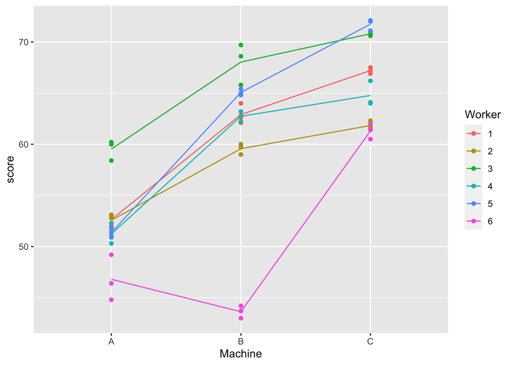

```r
ggplot(Machines, aes(x = Machine, y = score, group = Worker, col = Worker)) +
  geom_point() + stat_summary(fun.y = mean, geom = "line")
```

We observe that productivity is largest on machine $C$, followed by $B$ and $A$. Most workers show a similar “profile,” with the exception of worker 6 who performs badly on machine $B$.

Let us now model this data. We assume that there is a population machine effect (think of an average “profile”), but each worker is allowed to have its own (random) deviation.
$$Y_{ijk} = \mu + \alpha_i + B_j + (\alpha B)_{ij} + \epsilon_{ijk}$$
where $Y_{ijk}$ denotes the $k$th productivity score of worker $j$ on machine $i$. (Note that we use $B$ for the random-effect of worker here which is different in the notes.)

We assume the worker and the interaction random-effects are normally distributed
$$B_j \overset{iid}{\sim} \mathcal{N}(0, \sigma_\beta^2), \; (\alpha B)_{ij} \overset{iid}{\sim} \mathcal{N}(0, \sigma^2_{\alpha B}).$$

### Q1a What is the covariance of productivity score the same worker gets between different operations using the same machine, i.e. $\mbox{Cov}(Y_{ijk}, Y_{ijl})$ for $k \ne l$?

$$\begin{aligned}
\mbox{Cov}(Y_{ijk}, Y_{ijl}) &= \mbox{Cov}(B_j + (\alpha B)_{ij} + \epsilon_{ijk}, B_j + (\alpha B)_{ij} + \epsilon_{ijl})\\
&= \mbox{Var}(B_j + (\alpha B)_{ij})\\
&= \sigma_\beta^2 + \sigma^2_{\alpha B}\\
\end{aligned}$$

### Q1b What is the covariance of productivity score of the same worker using different machines, i.e. $\mbox{Cov}(Y_{ijk}, Y_{ljm})$ for $i \ne l$?

$$\begin{aligned}
\mbox{Cov}(Y_{ijk}, Y_{ljm}) &= \mbox{Cov}(B_j + (\alpha B)_{ij} + \epsilon_{ijk}, B_j + (\alpha B)_{lj} + \epsilon_{ljm})\\
&= \mbox{Var}(B_j)\\
&= \sigma_\beta^2\\
\end{aligned}$$
We could use the `lme4` package to fit such a model. We want to have

- a random effect $B_j$ per worker: `(1 | Worker)`
- a random effect $(\alpha B)_{ij}$ per combination of worker and machine: `(1 | Worker:Machine)`

Hence, the `lmer` call would look like this

```r
library(lme4)
fit <- lmer(score ~ Machine + (1 | Worker) + (1 | Worker:Machine), data = Machines)
```

As `lme4` does not calculate p-values for the fixed effects, we use the package `lmerTest` instead. Technically speaking, it is nothing else than a wrapper for the same function in package `lme4` but with modified outputs which include p-values.

```r
options(contrasts = c("contr.treatment", "contr.poly"))
library(lmerTest)
fit <- lmer(score ~ Machine + (1 | Worker) + (1 | Worker:Machine), data = Machines)
```

We get the ANOVA table with the function `anova`.

```r
anova(fit)
```

```
## Type III Analysis of Variance Table with Satterthwaite's method
##         Sum Sq Mean Sq NumDF DenDF F value    Pr(>F)
## Machine 38.051  19.025     2    10  20.576 0.0002855 ***
## ---
## Signif. codes:  0 '***' 0.001 '**' 0.01 '*' 0.05 '.' 0.1 ' ' 1
```

### Q1c For the ANOVA table above, we get a numerator df of $2$ and a denominator degree of freedom of $10$, why is the denominator degree of freedom so small?

For mixed-effects model, we test the main effect by using $F_A = \frac{MS[A]}{MS[AB]}$. The $df = 10$ comes from the interaction df.

### Q1d Finish the Df table below

| Source | df | (F)ixed/(R)andom |
| --- | --- | --- |
| Machine |  |  |
| Worker |  |  |
| Machine x Worker |  |  |
| Error |  |  |
| Total |  |  |

| Source | df | (F)ixed/(R)andom |
| --- | --- | --- |
| Machine | 2 | F |
| Worker | 5 | R |
| Machine x Worker | 10 | R |
| Error | 36 | R |
| Total | 53 |  |

Now take a look over the `summary`

```r
summary(fit)
```

```
## Linear mixed model fit by REML. t-tests use Satterthwaite's method [
## lmerModLmerTest]
## Formula: score ~ Machine + (1 | Worker) + (1 | Worker:Machine)
##    Data: Machines
##
## REML criterion at convergence: 215.7
##
## Scaled residuals:
##      Min       1Q   Median       3Q      Max
## -2.26959 -0.54847 -0.01071  0.43937  2.54006
##
## Random effects:
##  Groups         Name        Variance Std.Dev.
##  Worker:Machine (Intercept) 13.9095  3.7295
##  Worker         (Intercept) 22.8584  4.7811
##  Residual                    0.9246  0.9616
## Number of obs: 54, groups:  Worker:Machine, 18; Worker, 6
##
## Fixed effects:
##             Estimate Std. Error     df t value Pr(>|t|)
## (Intercept)   52.356      2.486  8.522  21.062 1.20e-08 ***
## MachineB       7.967      2.177 10.000   3.660  0.00439 **
## MachineC      13.917      2.177 10.000   6.393 7.91e-05 ***
## ---
## Signif. codes:  0 '***' 0.001 '**' 0.01 '*' 0.05 '.' 0.1 ' ' 1
##
## Correlation of Fixed Effects:
##          (Intr) MachnB
## MachineB -0.438
## MachineC -0.438  0.500
```

### Q1e How do you interprete The estimate of `MachineB` = 7.967?

The productivity score on machine $B$ is $7.967$ larger than machine $A$ on average (because it affects the mean of the response).

## Q2 Cheese data example

Now we continue with the Cheese data set example. A group of 10 “rural” and 10 “urban” raters rated 4 different cheese types ($A, B, C, D$). Every rater got to eat two samples from the same cheese type in random order. Hence, we have a total of $20 \times 4 \times 2 = 160$ observations.

```r
cheese <- read.table("http://stat.ethz.ch/~meier/teaching/data/cheese.dat", header = TRUE)
cheese[, "rater"] <- factor(cheese[, "rater"])
str(cheese)
```

```
## 'data.frame':    160 obs. of  4 variables:
##  $ cheese    : chr  "A" "A" "B" "B" ...
##  $ rater     : Factor w/ 10 levels "1","2","3","4",..: 1 1 1 1 1 1 1 1 2 2 ...
##  $ background: chr  "rural" "rural" "rural" "rural" ...
##  $ y         : int  67 66 51 53 75 70 68 66 76 76 ...
```

Note that the factor `rater` has only 10 levels. We have to be careful here and should not forget that rater is actually nested in background (so, the raters labeled “1” in the urban and the rural group have nothing in common).

We can easily visualize this data with an interaction plot. We use the package `ggplot2` to get a more appealing plot compared to the function `interaction` (R code for interested readers only).

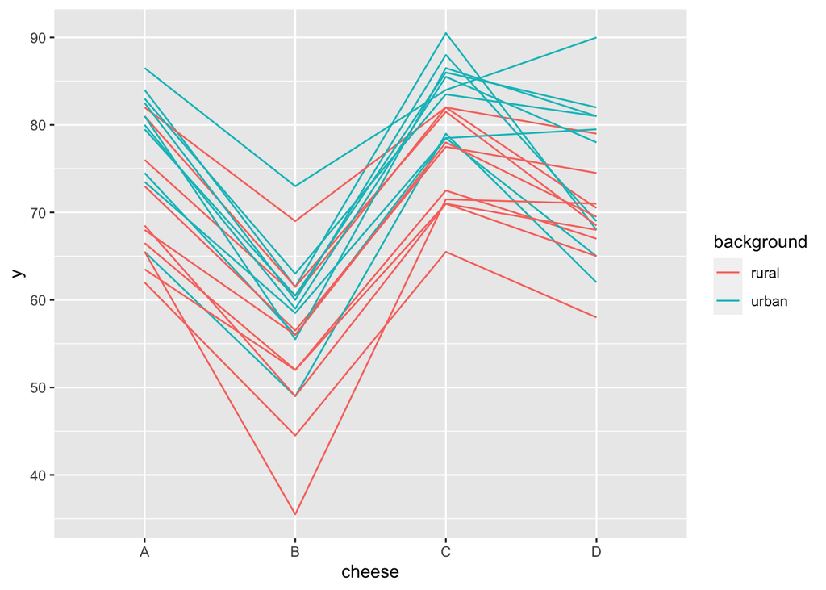

```r
ggplot(cheese, aes(x = cheese, y = y, group = interaction(background, rater),
                   color = background)) + stat_summary(fun.y = mean, geom = "line")
```

We treat background and cheese type as fixed-effects, and treat rater as random effect nested in background. The interaction between cheese type and rater is also a random effect.

$$Y_{ijkl} = \mu + \alpha_i + \beta_j + (\alpha \beta)_{ij} + C_{k(i)} + (\beta C)_{jk(i)} + \epsilon_{ijkl}$$

We can fit the model using

```r
library(lmerTest)
fit <- lmer(y ~ background * cheese + (1 | rater:background) +
              (1 | rater:background:cheese), data = cheese)
```

And get an ANOVA table with p-value for the fixed effects with the function `anova`.

```r
anova(fit)
```

```
## Type III Analysis of Variance Table with Satterthwaite's method
##                    Sum Sq Mean Sq NumDF DenDF  F value Pr(>F)
## background          82.13   82.13     1    18   8.2590 0.0101 *
## cheese            3144.66 1048.22     3    54 105.4149 <2e-16 ***
## background:cheese   15.42    5.14     3    54   0.5168 0.6725
## ---
## Signif. codes:  0 '***' 0.001 '**' 0.01 '*' 0.05 '.' 0.1 ' ' 1
```

### Q2a Finish the df table below

| Source | df | (F)ixed/(R)andom |
| --- | --- | --- |
| Background |  |  |
| Cheese type |  |  |
| Background $\times$ Cheese type |  |  |
| Rater |  |  |
| Rater $\times$ Background |  |  |
| Error |  |  |
| Total |  |  |

| Source | df | (F)ixed/(R)andom |
| --- | --- | --- |
| Background | 1 | F |
| Cheese type | 3 | F |
| Background $\times$ Cheese type | 3 | F |
| Rater | 18 | R |
| Rater $\times$ Background | 54 | R |
| Error | 80 | R |
| Total | 159 |  |

### Q2b Now explain the dfs for each of the $F$-statistic associated with each fixed effect.

We can take a look of the summary.

```r
summary(fit)
```

```
## Linear mixed model fit by REML. t-tests use Satterthwaite's method [
## lmerModLmerTest]
## Formula:
## y ~ background * cheese + (1 | rater:background) + (1 | rater:background:cheese)
##    Data: cheese
##
## REML criterion at convergence: 935.3
##
## Scaled residuals:
##      Min       1Q   Median       3Q      Max
## -2.22169 -0.47339 -0.00943  0.60686  1.61640
##
## Random effects:
##  Groups                  Name        Variance Std.Dev.
##  rater:background:cheese (Intercept) 13.819   3.717
##  rater:background        (Intercept) 28.342   5.324
##  Residual                             9.944   3.153
## Number of obs: 160, groups:  rater:background:cheese, 80; rater:background, 20
##
## Fixed effects:
##                         Estimate Std. Error      df t value Pr(>|t|)
## (Intercept)               70.600      2.171  34.536  32.519  < 2e-16 ***
## backgroundurban            8.400      3.070  34.536   2.736  0.00975 **
## cheeseB                  -16.950      1.939  54.000  -8.743 6.34e-12 ***
## cheeseC                    4.650      1.939  54.000   2.399  0.01994 *
## cheeseD                   -1.500      1.939  54.000  -0.774  0.44245
## backgroundurban:cheeseB   -2.450      2.742  54.000  -0.894  0.37548
## backgroundurban:cheeseC    0.350      2.742  54.000   0.128  0.89889
## backgroundurban:cheeseD   -1.950      2.742  54.000  -0.711  0.47998
## ---
## Signif. codes:  0 '***' 0.001 '**' 0.01 '*' 0.05 '.' 0.1 ' ' 1
##
## Correlation of Fixed Effects:
##             (Intr) bckgrn cheesB cheesC cheesD bckg:B bckg:C
## backgrndrbn -0.707
## cheeseB     -0.446  0.316
## cheeseC     -0.446  0.316  0.500
## cheeseD     -0.446  0.316  0.500  0.500
## bckgrndrb:B  0.316 -0.446 -0.707 -0.354 -0.354
## bckgrndrb:C  0.316 -0.446 -0.354 -0.707 -0.354  0.500
## bckgrndrb:D  0.316 -0.446 -0.354 -0.354 -0.707  0.500  0.500
```